# Лекция 6. Взвешивание и дважды робастные оценки

Блок 1. Отбор по наблюдаемым

Карен Аванесян

Каузальный анализ в R на данных RLMS-HSE

# Зачем

## Третий способ сделать то же самое

|  | Регрессия | Мэтчинг | Взвешивание |
| --- | --- | --- | --- |
| Что делает с $X$ | моделирует исход | подбирает похожих | перевзвешивает выборку |
| Какие единицы использует | все | подмножество | все, с весами |
| Эстиманд по умолчанию | «регрессионные веса» | ATT | ATE, ATT, ATO — на выбор |
| Чувствительность к модели | к модели исхода | к модели PS (баланс проверяем) | к модели PS (баланс проверяем), к экстремальным весам |

**Дважды робастная** оценка объединяет модель исхода и модель назначения: достаточно, чтобы **хотя бы одна** была верной. Это стандарт для оценок по наблюдаемым.

## План занятия

1. Обратные вероятности как «псевдопопуляция»
2. Веса для ATE, ATT, ATO; стабилизация и обрезание
3. Диагностика: баланс и эффективный размер выборки
4. G-computation: регрессия как машина контрфактов
5. AIPW: почему «дважды»
6. Симуляция двойной робастности

# Идея

## Обратные вероятности

Если $e(X) = P(D = 1 \mid X)$, то взвешивание

$$w_i = \frac{D_i}{e(X_i)} + \frac{1 - D_i}{1 - e(X_i)}$$

создаёт **псевдопопуляцию**, в которой $D$ не зависит от $X$: каждый обработанный «представляет» $1/e$ таких же людей, включая тех, кто воздействия не получил.

ATE

### Вся популяция

Взвешенная разница средних = ATE (при условной независимости и общей поддержке)

ATT

### Обработанные

Обработанные с весом 1, контроли — $e / (1 - e)$

ATO

### Overlap

$1 - e$ для обработанных, $e$ для контролей — больше веса тем, кто мог оказаться в любой группе

## Экстремальные веса

- $e(X) = 0.01$ → вес 100: один человек «отвечает» за сотню. Дисперсия оценки взлетает
- Это сигнал о **слабой поддержке**, а не техническая проблема: такие люди почти никогда не получают воздействие
- Что делать: стабилизировать ($\bar e / e$), обрезать (trim 1 %), сменить эстиманд (ATT, ATO), проверить спецификацию PS
- **ESS** — эффективный размер выборки: $(\sum w)^2 / \sum w^2$. Если ESS упал с 4 000 до 300, доверительный интервал будет соответствующим

## G-computation: регрессия как машина контрфактов

**Оценить** модель исхода $\hat\mu(d, X)$ — например, регрессию с взаимодействиями $D \times X$

**Предсказать** для **каждого** человека $\hat\mu(1, X_i)$ и $\hat\mu(0, X_i)$

**Усреднить**: ATE = среднее разностей; ATT — среднее по обработанным

- Это и есть «стандартизация» в эпидемиологии и «regression adjustment» в экономике
- `marginaleffects::avg_comparisons()` делает ровно это, с корректными ошибками
- Требует правильной модели исхода. Экстраполирует там, где нет поддержки — молча

## AIPW: сложить два подхода

$$\hat\tau_{AIPW} = \frac{1}{n}\sum_i \left[ \hat\mu(1, X_i) - \hat\mu(0, X_i) + \frac{D_i (Y_i - \hat\mu(1, X_i))}{\hat e(X_i)} - \frac{(1 - D_i)(Y_i - \hat\mu(0, X_i))}{1 - \hat e(X_i)} \right]$$

- Первая часть — g-computation; вторая — взвешенная поправка на ошибки модели исхода
- Если модель исхода верна, поправка в среднем 0. Если верна модель PS, поправка исправляет ошибки модели исхода
- Практический эквивалент: **взвешенная регрессия с ковариатами** (веса IPW) — тоже дважды робастна
- Та же конструкция лежит в основе causal forest (лекция 16), Double ML и TMLE

# Код

## Веса для ATT

Воздействие — обучение за последние 12 месяцев (`training_12m`), RLMS 2019, работающие 25–60 лет:

```r
W_att <- weightit(f_ps, data = tr, method = "glm", estimand = "ATT")
summary(W_att)                                 # вывод — на следующем слайде
```

- `method = "glm"` — логит-модель PS по формуле `f_ps` (прошлая зарплата, пол, возраст, образование, тип занятости, профессия, отрасль)
- `estimand = "ATT"` — обученные получают вес 1, контроли — $e(X)/(1 - e(X))$
- Веса лежат в `W_att$weights`; первое, что с ними делают, — `summary()`

## Как читать вывод `summary()` весов

- Вывод R
- С пояснениями

```
                  Summary of weights

─ Weight ranges:

        Min                                 Max
Treated   1                              │ 1.
Control   0  ╞════════════════╡            0.63

─ Units with the 5 most extreme weights by group:

            37    17   16    13   11
 Treated     1     1    1     1    1
          1353  1760 1715  2915 2476
 Control 0.486 0.493 0.55 0.604 0.63

─ Weight statistics:

        Coef of Var   MAD Entropy # Zeros
Treated        0.   0.      0.          0
Control        1.15 0.817   0.512       0

─ Effective Sample Sizes:

           Control Treated
Unweighted    4353     276
Weighted      1867     276
```

1 · Weight ranges

Мин. и макс. веса по группам и «гистограмма» из символов. Для ATT у обученных все веса = 1; у контролей — от 0 до 0.63

2 · 5 most extreme

Номера строк и веса пяти самых «тяжёлых» людей в группе. Посмотрите на них в данных: кто они и почему почти не похожи на другую группу

3 · Coef of Var

Разброс весов: sd / среднее. Связан с ESS: $n / (1 + CV^2)$ = 1867 ≈ ESS контролей

4 · MAD, Entropy, # Zeros

Другие меры неравномерности весов (чем больше, тем хуже). **# Zeros** — сколько людей выброшено совсем (бывает при обрезании и мэтчинге)

5 · Effective Sample Sizes

Сколько «независимых» наблюдений стоят веса: контролей было 4353, стало 1867. Обученные не изменились — их вес 1

6 · сигналы беды

Один-два веса на порядок больше остальных; ESS группы упал в разы; веса для ATE в сотнях. Это слабая общая поддержка, а не «шум»

## Баланс после взвешивания

- Результат
- Код

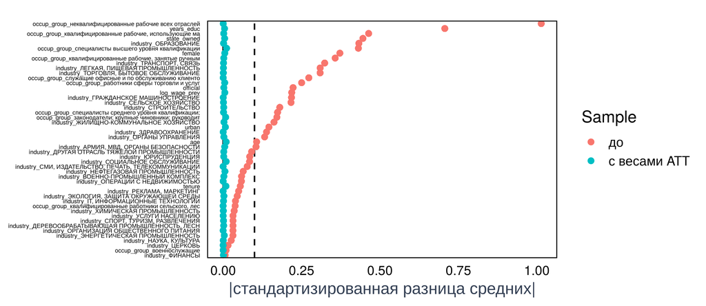

```r
love.plot(W_att, binary = "std", abs = TRUE, thresholds = c(m = 0.1), var.order = "unadjusted",
          drop.distance = TRUE, sample.names = c("до", "с весами ATT"), title = NULL) +
  labs(x = "|стандартизированная разница средних|")
```

## Как читать вывод `bal.tab()`

- Вывод R
- С пояснениями

```r
bal.tab(W_att, binary = "std", un = TRUE, thresholds = c(m = 0.1))
```

```
Balance Measures
                   Type Diff.Un Diff.Adj    M.Threshold
prop.score     Distance   0.865    0.034 Balanced, <0.1
log_wage_prev   Contin.   0.219    0.005 Balanced, <0.1
female           Binary   0.372    0.005 Balanced, <0.1
age             Contin.  -0.107    0.010 Balanced, <0.1
years_educ      Contin.   0.707    0.004 Balanced, <0.1
urban            Binary   0.146    0.007 Balanced, <0.1
official         Binary   0.223   -0.002 Balanced, <0.1
state_owned      Binary   0.446    0.005 Balanced, <0.1
tenure          Contin.   0.055    0.009 Balanced, <0.1
   … ещё 40 дамми профессий и отраслей

Balance tally for mean differences
                   count
Balanced, <0.1        49
Not Balanced, >0.1     0

Effective sample sizes
           Control Treated
Unadjusted    4353     276
Adjusted      1867     276
```

1 · Type

`Distance` — сам PS, `Contin.` — непрерывная, `Binary` — дамми. Факторы `occup_group` и `industry` развёрнуты в дамми по уровням

2 · Diff.Un

Стандартизированная разница средних **до** взвешивания (`binary = "std"` — и для дамми). Годы обучения: 0.71 SD — обучаются более образованные

3 · Diff.Adj

То же **после** взвешивания. Цель — |SMD| < 0.1. Максимум здесь — 0.034

4 · M.Threshold и tally

Метка по порогу `thresholds = c(m = 0.1)` у каждой переменной и итог: сколько сбалансировано, сколько нет

5 · Effective sample sizes

Те же ESS, что в `summary()`: цена баланса. Хороший баланс при крошечном ESS — плохая сделка

6 · сигналы беды

`Not Balanced` у сильных конфаундеров; баланс только средних — проверьте дисперсии (`disp.v.ratio = TRUE`) и распределения (`stats = "ks.statistics"`)

## Распределение весов: где прячутся экстремумы

Для ATT веса контролей скромные (обучение — редкое событие). А вот веса **для ATE** у обученных с низким $e(X)$ взлетают:

- Результат
- Код

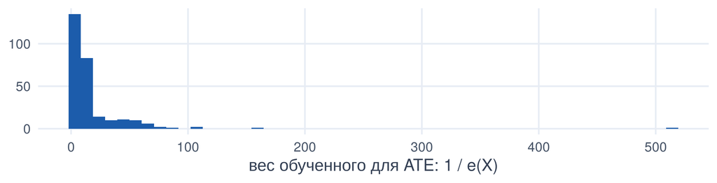

| ESS | макс | доля весов > 20 |
| --- | --- | --- |
| 56.5 | 514 | 0.199 |

```r
W_ate <- weightit(f_ps, data = tr, method = "glm", estimand = "ATE")
tr$w_ate <- W_ate$weights
ggplot(tr |> filter(treat == 1), aes(w_ate)) +
  geom_histogram(bins = 50, fill = pal["indigo"]) +
  labs(x = "вес обученного для ATE: 1 / e(X)", y = NULL)
tr |> filter(treat == 1) |> summarise(ESS = sum(w_ate)^2 / sum(w_ate^2), макс = max(w_ate),
                                      `доля весов > 20` = mean(w_ate > 20))
```

## Обрезание

```r
W_trim <- trim(W_ate, at = 0.99)                     # обрезать верхний 1 % весов
stat <- function(W, name) tibble(
  веса = name,
  `ESS обученных` = summary(W)$effective.sample.size["Weighted", "Treated"],
  `макс |SMD|`    = max(abs(bal.tab(W, binary = "std")$Balance$Diff.Adj)))
bind_rows(stat(W_ate, "как есть"), stat(W_trim, "обрезаны 1 %")) |>
  mutate(across(where(is.numeric), ~ round(.x, 2)))
```

| веса | ESS обученных | макс \|SMD\| |
| --- | --- | --- |
| как есть | 56.5 | 0.6 |
| обрезаны 1 % | 191.3 | 0.3 |

## Оценка эффекта с весами: честные ошибки

```r
fit_w <- lm_weightit(f_y, data = tr, weightit = W_att)          # учитывает оценку весов
att_w <- avg_comparisons(fit_w, variables = "treat", newdata = subset(tr, treat == 1))
att_w |> as_tibble() |> select(estimate, std.error, conf.low, conf.high)
```

| estimate | std.error | conf.low | conf.high |
| --- | --- | --- | --- |
| 0.047 | 0.026 | -0.005 | 0.099 |

- `lm_weightit()` считает стандартные ошибки через M-оценивание — с учётом того, что веса сами оценены
- Регрессия с ковариатами **плюс** веса = дважды робастная оценка ATT

## Как читать вывод `avg_comparisons()`

- Вывод R
- С пояснениями

```
  Term Contrast Estimate Std. Error    z Pr(>|z|)   S    2.5 % 97.5 %
 treat    1 - 0   0.0469     0.0265 1.77   0.0766 3.7 -0.00501 0.0988

Columns: term, contrast, estimate, std.error, statistic, p.value, s.value, conf.low, conf.high
Type:  response
```

1 · Term, Contrast

`treat`, `1 - 0`: для каждого человека предсказание при $D = 1$ минус при $D = 0$, затем среднее. `newdata` = только обученные → это **ATT**

2 · Estimate

В единицах исхода: 0.047 лог-пункта ≈ +4.8 % к зарплате обученных

3 · Std. Error

Из `vcov` модели: у `lm_weightit()` по умолчанию `"asympt"` — M-оценивание, учитывает, что веса оценены. Обычный `lm(weights = )` этого не делает

4 · z, Pr(>|z|), S

Нормальный тест против нуля: p = 0.077, S = 3.7 бита — слабое свидетельство

5 · 2.5 % и 97.5 %

95 %-й ДИ: от -0.005 до 0.099. Включает ноль, но исключает эффекты больше 0.1 (≈ 10 %)

6 · сигналы беды

Забыли `newdata` — получили ATE, а не ATT; `Contrast` не `1 - 0` (например, `+1`): `treat` закодирован не как 0/1; SE из `lm()` с весами вместо `lm_weightit()`

## Как писать результат

шаблон

«Среди работающих 25–60 лет в RLMS 2019 г. (276 прошедших обучение, 4353 контролей) дважды робастная оценка ATT — взвешивание по обратной вероятности (логит-PS) плюс регрессия исхода — составляет **0.047** лог-пункта (s.e. 0.026; 95 % ДИ от -0.005 до 0.099). После взвешивания все |SMD| < 0.1; эффективный размер контрольной группы — 1867. Оценка опирается на допущение, что при учтённых характеристиках, включая зарплату год назад, решение об обучении не связано с ненаблюдаемыми детерминантами зарплаты.»

- Обязательно: эстиманд (ATT), модель PS и модель исхода, баланс и ESS, как считались ошибки, было ли обрезание
- Не писать «обучение не влияет на зарплату»: интервал широкий и включает как ноль, так и заметные эффекты

## Энтропийное балансирование

```r
W_ebal <- weightit(f_ps, data = tr, method = "ebal", estimand = "ATT")
b_ebal <- bal.tab(W_ebal, binary = "std")$Balance$Diff.Adj
round(c(`макс |SMD| после ebal` = max(abs(b_ebal)),
        `ESS контролей` = summary(W_ebal)$effective.sample.size["Weighted", "Control"]), 3)
```

```
макс |SMD| после ebal         ESS контролей
                0.001              1853.407
```

- Вместо модели PS — ищем веса, при которых средние (и дисперсии) ковариат **точно** совпадают
- Баланс гарантирован по построению; цена — дисперсия, если профили групп сильно различаются

## G-computation без весов

```r
fit_g <- lm(f_y, data = tr)
avg_comparisons(fit_g, variables = "treat", vcov = "HC3", newdata = subset(tr, treat == 1)) |>
  as_tibble() |> select(estimate, std.error, conf.low, conf.high)
```

| estimate | std.error | conf.low | conf.high |
| --- | --- | --- | --- |
| 0.057 | 0.028 | 0.002 | 0.113 |

- Та же регрессия, без весов: ATT из модели исхода
- Близко к взвешенной оценке — хороший знак: обе модели «согласны»

## Лестница оценок, продолжение

| метод | оценка | se |
| --- | --- | --- |
| наивная разница | 0.160 | 0.039 |
| g-computation (регрессия), ATT | 0.057 | 0.028 |
| IPW + регрессия (DR), ATT | 0.047 | 0.026 |
| энтропийные веса + регрессия, ATT | 0.047 | 0.027 |
| IPW, ATE (вся популяция) | 0.050 | 0.027 |
| overlap-веса, ATO | 0.064 | 0.034 |

## Симуляция: что значит «дважды»

Истинный эффект = 2; PS и исход нелинейны по $x_2$. 200 повторов по 4000 наблюдений.

- Результат
- Код

| оценка | среднее | sd |
| --- | --- | --- |
| IPW, PS верен | 2.02 | 0.18 |
| IPW, PS неверен | 3.10 | 0.07 |
| g-comp, исход верен | 2.00 | 0.03 |
| g-comp, исход неверен | 3.10 | 0.07 |
| DR: PS неверен, исход верен | 2.00 | 0.04 |
| DR: PS верен, исход неверен | 2.04 | 0.11 |
| DR: оба неверны | 3.10 | 0.07 |

```r
dgp <- function(n = 4000) {
  tibble(x1 = rnorm(n), x2 = rnorm(n)) |>
    mutate(e = plogis(-0.3 + 0.6 * x1 + 0.5 * x2^2),      # PS нелинеен по x2
           d = rbinom(n, 1, e),
           y = 1 + 2 * d + x1 + 1.5 * x2^2 + rnorm(n))      # исход тоже нелинеен; эффект = 2
}
one_rep <- function() {
  s <- dgp()
  ps_ok  <- fitted(glm(d ~ x1 + I(x2^2), s, family = binomial))      # верный PS
  ps_bad <- fitted(glm(d ~ x1 + x2,       s, family = binomial))      # пропущен квадрат
  w <- function(ps) ifelse(s$d == 1, 1 / ps, 1 / (1 - ps))
  gcomp <- function(m) mean(predict(m, mutate(s, d = 1)) - predict(m, mutate(s, d = 0)))
  g  <- function(f) gcomp(lm(f, s))
  dr <- function(ps, f) { s$ww <- w(ps); gcomp(lm(f, s, weights = ww)) }
  c(`IPW, PS верен` = unname(coef(lm(y ~ d, s, weights = w(ps_ok)))["d"]),
    `IPW, PS неверен` = unname(coef(lm(y ~ d, s, weights = w(ps_bad)))["d"]),
    `g-comp, исход верен` = g(y ~ d * (x1 + I(x2^2))),
    `g-comp, исход неверен` = g(y ~ d * (x1 + x2)),
    `DR: PS неверен, исход верен` = dr(ps_bad, y ~ d * (x1 + I(x2^2))),
    `DR: PS верен, исход неверен` = dr(ps_ok, y ~ d * (x1 + x2)),
    `DR: оба неверны` = dr(ps_bad, y ~ d * (x1 + x2)))
}
set.seed(66)
res <- replicate(200, one_rep())
tibble(оценка = rownames(res), среднее = rowMeans(res), sd = apply(res, 1, sd)) |>
  mutate(across(where(is.numeric), ~ round(.x, 2)))
```

## Что показала симуляция

# Как ошибаются

## Шесть ошибок с весами

1. Не смотрят на распределение весов: один человек с весом 80 определяет результат
2. Считают ATE там, где нет поддержки: для части людей воздействие практически невозможно
3. Стандартные ошибки «как будто веса известны» — занижены; нужны M-оценки или бутстрэп
4. Модель PS с переменными, измеренными после воздействия
5. Оптимизируют PS на предсказание (AUC), а не на баланс
6. Называют DR-оценку «робастной» без проверки, что хотя бы одна модель правдоподобна

## Чек-лист

- Эстиманд выбран осознанно: ATE / ATT / ATO — и объяснён
- Показаны распределение весов, ESS, обрезание (если есть)
- Баланс после взвешивания: SMD < 0.1
- Оценка — взвешенная регрессия с ковариатами (DR)
- Ошибки учитывают оценку весов (`lm_weightit`, бутстрэп)
- Результат сравнён с g-computation и мэтчингом: расхождения объяснены

# Мини-задача

## Задание к следующему занятию

1. Пересчитайте ATT через IPW для 2016 и 2023 годов. Сравните с мэтчингом из прошлого задания
2. Постройте веса ATE и найдите 10 человек с максимальными весами. Кто они? Что произойдёт с оценкой, если их убрать?
3. В симуляции двойной робастности замените линейные модели на `ranger` (случайный лес) для PS и исхода. Что произошло со смещением в случае «оба неверны»?
4. Оцените эффект **курения** на `good_health` взвешиванием (ATT) с теми же ковариатами, что в задании по мэтчингу. Насколько различаются оценки IPW и мэтчинга? Почему?

# Литература

## Что прочитать

- Hernán M., Robins J. *What If*, гл. 12–13 — IP weighting и standardization, одна глава за другой
- Robins J., Rotnitzky A., Zhao L. (1994). Estimation of Regression Coefficients When Some Regressors Are Not Always Observed. *JASA* — исток AIPW
- Li F., Morgan K., Zaslavsky A. (2018). Balancing Covariates via Propensity Score Weighting. *JASA* — overlap-веса
- Hainmueller J. (2012). Entropy Balancing for Causal Effects. *Political Analysis*
- Greifer N. Виньетки [`WeightIt`](https://ngreifer.github.io/WeightIt/) «Estimating Effects After Weighting»
- Huntington-Klein N. *The Effect*, гл. 14 «Matching» (включая взвешивание)

Каузальный анализ в R · RLMS-HSE · К. Аванесян

← К программе курса